# HW5

## Eksperyment 1

W pierwszym mini-eksperymencie chciałem sprawdzić czy osoby które nie zajmują się analizą danych i nie mają doświadczenia z tworzeniem wykresów zauważą czy na wykresie są tak zwane “latające słupki”. Wykonałem dwa takie same wykresy w których na jednym występuje ten problem, a na drugim nie.

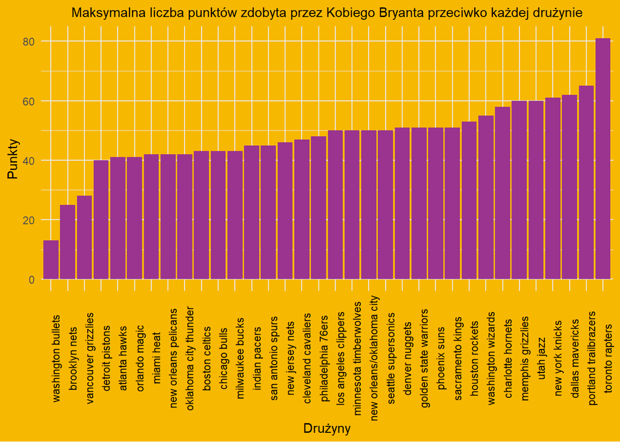

```r
df %>%
  filter(minutes_played!="Null" & !is.na(points)) %>%
  mutate(points = as.integer(points)) %>%
  group_by(opponent) %>%
  summarise(max = max(points, na.rm = TRUE)) %>%
  arrange(-max) %>%
  ggplot(aes(x = reorder(opponent, max), y = max)) +
  geom_col(fill = "#9A348E") +
  theme_minimal() +
  theme(
    axis.text.x = element_text(angle = 90, color = "black"),
    plot.title = element_text(size = 11, hjust = 0.5),
    plot.background = element_rect(fill = "#F7B801", color = NA)
  ) +
  labs(
    title = "Maksymalna liczba punktów zdobyta przez Kobiego Bryanta przeciwko każdej drużynie",
    x = "Drużyny",
    y = "Punkty"
    )
```

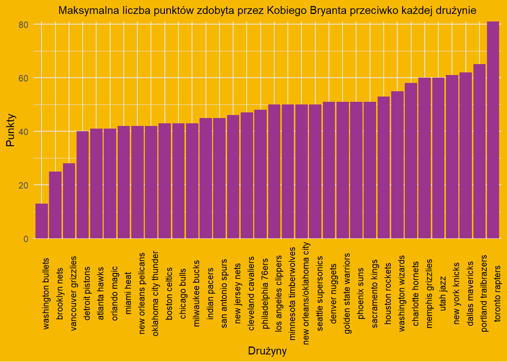

```r
df %>%
  filter(minutes_played!="Null" & !is.na(points)) %>%
  mutate(points = as.integer(points)) %>%
  group_by(opponent) %>%
  summarise(max = max(points, na.rm = TRUE)) %>%
  arrange(-max) %>%
  ggplot(aes(x = reorder(opponent, max), y = max)) +
  geom_col(fill = "#9A348E") +
  theme_minimal() +
  scale_y_continuous(expand=c(0,0)) +
  theme(
    axis.text.x = element_text(angle = 90, color = "black"),
    plot.title = element_text(size = 11, hjust = 0.5),
    plot.background = element_rect(fill = "#F7B801", color = NA)
  ) +
  labs(
    title = "Maksymalna liczba punktów zdobyta przez Kobiego Bryanta przeciwko każdej drużynie",
    x = "Drużyny",
    y = "Punkty"
  )
```

## Wynik eksperymentu 1

Po części zgodnie z moimi przewidywaniami nie wszyscy zauważali różnicę na tych dwóch wykresach, gdy były one przedstawione jeden pod drugim. Jednak ku mojemy zaskoczeniu większość osób które zauważyły różnicę i tak uważały że wykres na którym są “latające słupki” jest lepszy niż ten teoretycznie poprawny bez nich.

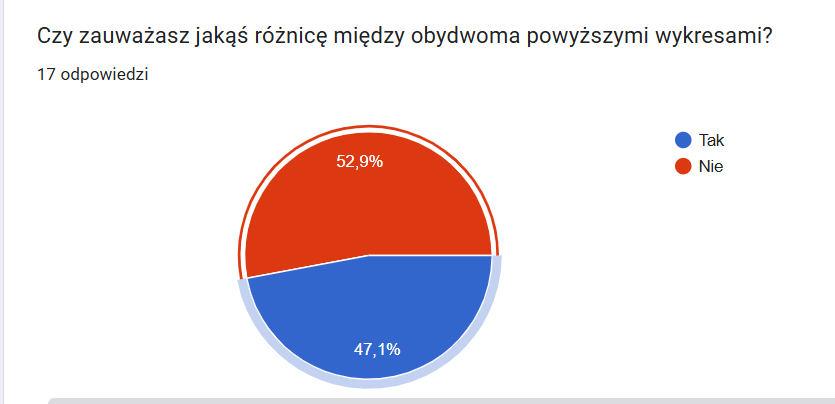

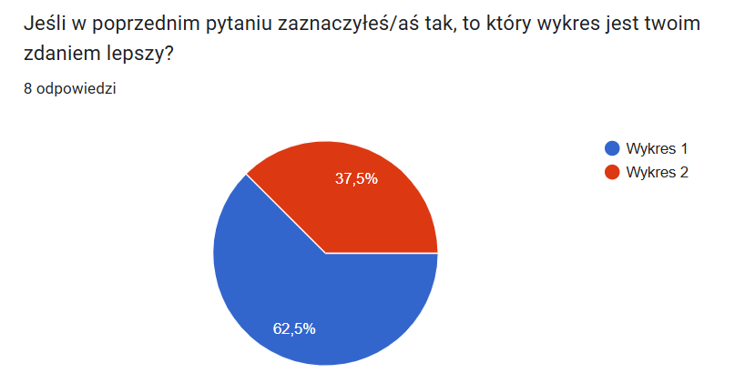

## Eksperyment 2

W tym eksperymencie badałem czy używanie zbyt dużej ilości kolorów powoduje że wykres staje się mniej czytelny i przez to nie będzie preferowany prze osoby które go oglądają.

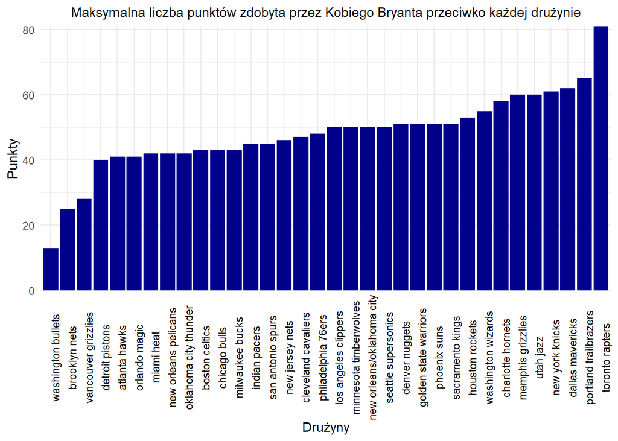

```r
df %>%
  filter(minutes_played!="Null" & !is.na(points)) %>%
  mutate(points = as.integer(points)) %>%
  group_by(opponent) %>%
  summarise(max = max(points, na.rm = TRUE)) %>%
  arrange(-max) %>%
  ggplot(aes(x = reorder(opponent, max), y = max)) +
  geom_col(fill="darkblue") +
  theme_minimal() +
  scale_y_continuous(expand=c(0,0)) +
  theme(
    axis.text.x = element_text(angle = 90, color = "black"),
    plot.title = element_text(size = 11, hjust = 0.5),
    legend.title = element_blank(),
    legend.text = element_blank(),
    legend.position = "none",
  ) +
  labs(
    title = "Maksymalna liczba punktów zdobyta przez Kobiego Bryanta przeciwko każdej drużynie",
    x = "Drużyny",
    y = "Punkty"
  )
```

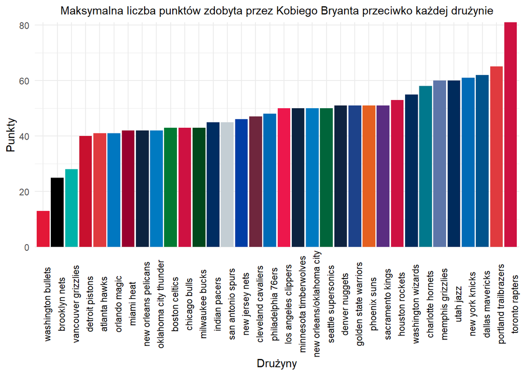

```r
df %>%
  filter(minutes_played!="Null" & !is.na(points)) %>%
  mutate(points = as.integer(points)) %>%
  group_by(opponent) %>%
  summarise(max = max(points, na.rm = TRUE)) %>%
  arrange(-max) %>%
  ggplot(aes(x = reorder(opponent, max), y = max, fill = opponent)) +
  geom_col() +
  theme_minimal() +
  scale_y_continuous(expand=c(0,0)) +
  scale_fill_manual(values = team_cols) +
  theme(
    axis.text.x = element_text(angle = 90, color = "black"),
    plot.title = element_text(size = 11, hjust = 0.5),
    legend.title = element_blank(),
    legend.text = element_blank(),
    legend.position = "none",
  ) +
  labs(
    title = "Maksymalna liczba punktów zdobyta przez Kobiego Bryanta przeciwko każdej drużynie",
    x = "Drużyny",
    y = "Punkty"
  )
```

## Wynik eksperymentu 2

Zgodnie z teorią tworzenia wykresów wykresów, wykres na którym każda drużyna została podwójnie oznaczona kolorem oraz podpisem na osi x nie był preferowany przez osoby ankietowane. Użycie kolorów które reprezentowały barwy klubów nie miało żadnego pozytywnego wpływu i większość ankietowanych wybrała wykres na których wszystkie słupki były w jednym kolorze.

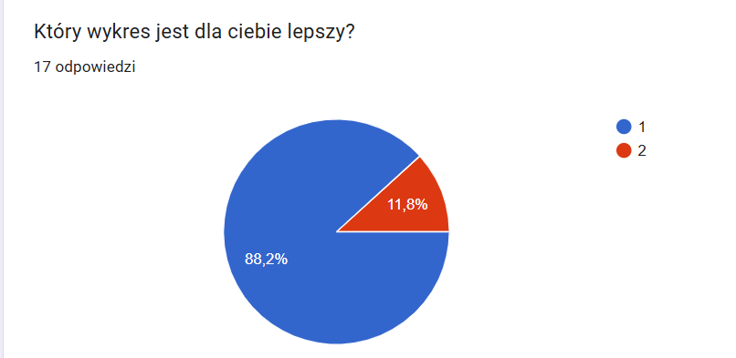